# P1) Tail Dependence

## I. Bivariate t-Distribution

توزیع با پارامترهای کوراریانس به صورت زیر

$$ \mathbf{\Sigma} = \begin{bmatrix} 1 & 0.5 \\ 0.5 & 1 \end{bmatrix} $$

و ماتریس شکل به صورت

$$ \text{Shape} = \frac{\nu - 2}{\nu} \mathbf{\Sigma} = \begin{bmatrix} \frac{1}{3} & \frac{0.5}{3} \\ \frac{0.5}{3} & \frac{1}{3} \end{bmatrix} $$

و درجه آزادی $\nu = 3$ انتخاب شده است.

اتفاق‌های دمی هر دو توزیع حاشیه‌ای مشخص شده است و نسبتی برای تعداد آنها محاسبه شده است.

[figure not shown]

```
Extreme Ratio (t-dist): 0.66%
```

```python
import numpy as np
import scipy.stats as stats
import matplotlib.pyplot as plt

# Parameters
v = 3
cov = np.array([[1, 0.5], [0.5, 1]])
shape = (cov * (v - 2)) / v

# Bivariate t-distribution
X_t = stats.multivariate_t(loc=[0,0], shape=shape, df=v).rvs(5000)

# Identify JOINT tail events (both variables in tails)
q_x_left, q_x_right = np.quantile(X_t[:,0], [0.01, 0.99])
q_y_left, q_y_right = np.quantile(X_t[:,1], [0.01, 0.99])

joint_outliers = (
    ((X_t[:,0] < q_x_left) & (X_t[:,1] < q_y_left)) |
    ((X_t[:,0] > q_x_right) & (X_t[:,1] > q_y_right))
)

# Ratio of extreme events
extreme_count = joint_outliers.sum()
total_samples = len(X_t)
extreme_event_ratio = extreme_count / total_samples

# Plot
plt.figure(figsize=(8,6))
plt.scatter(X_t[:,0], X_t[:,1], s=1, alpha=0.3, color='blue')
plt.scatter(X_t[joint_outliers,0], X_t[joint_outliers,1],
            s=5, color='red', alpha=0.7, label=f'Joint tail ({outlier_ratio:.2%})')

plt.axvline(q_x_left, color='grey', linestyle='--', linewidth=0.8)
plt.axvline(q_x_right, color='grey', linestyle='--', linewidth=0.8)
plt.axhline(q_y_left, color='grey', linestyle='--', linewidth=0.8)
plt.axhline(q_y_right, color='grey', linestyle='--', linewidth=0.8)

plt.title('Bivariate t-Distribution: Joint Tail Events')
plt.legend()
plt.show()

print(f"Extreme Ratio (t-dist): {extreme_event_ratio:.2%}")
```

## II. Bivariate Normal Distribution

برای این توزیع ماتریس کوواریانس مساوی با توزیع قسمت قبل استفاده کردم.

[figure not shown]

```
Extreme Event Ratio (normal): 0.26%
```

```python
import numpy as np
import scipy.stats as stats
import matplotlib.pyplot as plt

# Parameters
corr = 0.5
cov = np.array([[1, corr], [corr, 1]])
n = 5000

# Generate normal data
X_n = stats.multivariate_normal(mean=[0, 0], cov=cov).rvs(n)

# Joint tail identification
q_x_left_n, q_x_right_n = np.quantile(X_n[:,0], [0.01, 0.99])
q_y_left_n, q_y_right_n = np.quantile(X_n[:,1], [0.01, 0.99])

joint_outliers_n = (
    ((X_n[:,0] < q_x_left_n) & (X_n[:,1] < q_y_left_n)) |
    ((X_n[:,0] > q_x_right_n) & (X_n[:,1] > q_y_right_n))
)

# Ratio of extreme events
extreme_count = joint_outliers_n.sum()
total_samples = len(X_n)
extreme_event_ratio = extreme_count / total_samples

# Plot with same styling
plt.figure(figsize=(8,6))
plt.scatter(X_n[:,0], X_n[:,1], s=1, alpha=0.3, color='blue')
plt.scatter(X_n[joint_outliers_n,0], X_n[joint_outliers_n,1],
            s=5, color='red', alpha=0.7, label=f'Joint tail ({outlier_ratio_n:.2%})')

plt.axvline(q_x_left_n, color='grey', linestyle='--', linewidth=0.8)
plt.axvline(q_x_right_n, color='grey', linestyle='--', linewidth=0.8)
plt.axhline(q_y_left_n, color='grey', linestyle='--', linewidth=0.8)
plt.axhline(q_y_right_n, color='grey', linestyle='--', linewidth=0.8)

plt.title('Bivariate Normal Distribution: Joint Tail Events')
plt.legend()
plt.show()

print(f"Extreme Event Ratio (normal): {extreme_event_ratio:.2%}")
```

## III. Analyze and Discuss

همانطور که در درس هم مشاهده شد وابستگی دمی در توزیع $\text{t-Student}$ بیشتر از توزیع نرمال است. این موضوع باعث می‌شود مواقعی که هر دو توزیع در حالت فرین قرار می‌گیرند بیشتر اتفاق بیفتد. این نسبت را در قسمت‌های پیش نشان دادم و مشاهده می‌شود که در توزیع $\text{t-Student}$ مقدار این نسبت بیشتر از دو برابر توزیع نرمال است.

وابستگی دمی بالا به صورت زیر

$$ \lambda_{\mathrm{upper}} = \lim_{q \to 1} P\left(X > F_X^{-1}(q) \mid Y > F_Y^{-1}(q)\right) $$

و وابستگی دمی پایین به صورت زیر

$$ \lambda_{\mathrm{lower}} = \lim_{q \to 0} P\left(X \leq F_X^{-1}(q) \mid Y \leq F_Y^{-1}(q)\right) $$

تعریف می‌شود. این مقدار در توزیع نرمال به سرعت به صفر میل می‌کند. ولی در توزیع توأم t این مقدار به صورت زیر است:

$$ \lambda_{\mathrm{upper}} = \lambda_{\mathrm{lower}} = 2 \cdot t_{\nu+1}\left( -\sqrt{\frac{(\nu+1)(1-\rho)}{1+\rho}} \right) $$

که مقدار آن کندتر به صفر می‌رسد.

# P2) Vasicek’s Model:

## I. Worst-Case Default Rate

رابطه بدترین نرخ نکول برای سطح اطمینان ۹۹.۹٪ به صورت زیر است $$ \text{WCDR} = \Phi\left( \frac{\Phi^{-1}(PD) + \sqrt{\rho} \cdot \Phi^{-1}(0.999)}{\sqrt{1 - \rho}} \right) $$ نمودار تابع را یک بار با فرض $\text{PD}=1%$ و تغییر همبستگی از ۰ تا ۱ و یک بار به ازای $\mathcal{\rho}=0.2$ و تغییر $\text{PD}$ از ۱٪ تا ۵۰٪ رسم کردم.

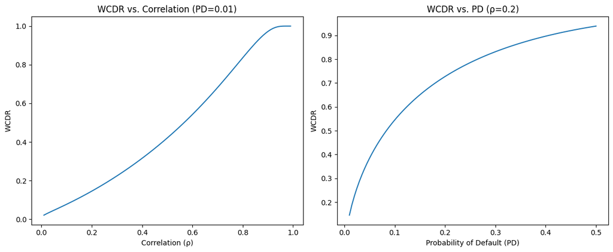

```python
import numpy as np
import scipy.stats as stats
import matplotlib.pyplot as plt

# Define WCDR function
def wcdr(pd, rho):
    numerator = stats.norm.ppf(pd) + np.sqrt(rho) * stats.norm.ppf(0.999)
    denominator = np.sqrt(1 - rho)
    return stats.norm.cdf(numerator / denominator)

# Fix PD and vary rho
pd_fixed = 0.01
rhos = np.linspace(0.01, 0.99, 100)
wcdr_rho = [wcdr(pd_fixed, rho) for rho in rhos]

# Fix rho and vary PD
rho_fixed = 0.2
pds = np.linspace(0.01, 0.5, 100)
wcdr_pd = [wcdr(pd, rho_fixed) for pd in pds]

# Plotting
plt.figure(figsize=(12, 5))

plt.subplot(1, 2, 1)
plt.plot(rhos, wcdr_rho)
plt.xlabel('Correlation (ρ)')
plt.ylabel('WCDR')
plt.title('WCDR vs. Correlation (PD=0.01)')

plt.subplot(1, 2, 2)
plt.plot(pds, wcdr_pd)
plt.xlabel('Probability of Default (PD)')
plt.ylabel('WCDR')
plt.title('WCDR vs. PD (ρ=0.2)')

plt.tight_layout()
plt.show()
```

## II. Extreme Event Modeling

تحلیل بهتر زمانی انجام شدنی می‌بود که همبستگی غیر خطی باشد؛ یعنی با افزایش $\text{PD}$ افزایش یابد. این موضوع بیشتر شبیه حالت همبستگی‌ای است که در نمودار ۹.۱ بخش (c) کتاب نمایش داده شده است. در این حالت توقع دارم هر دو پارامتر مقدارهای فرین بگیرند و در نتیجه $\text{WCDR}$ افزایش شدید پیدا کند.

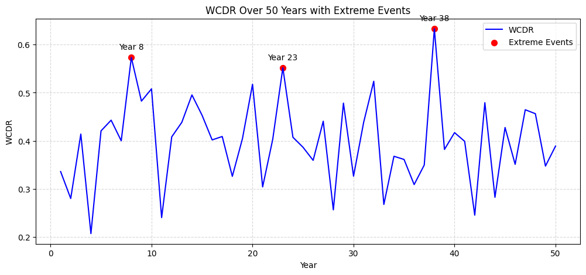

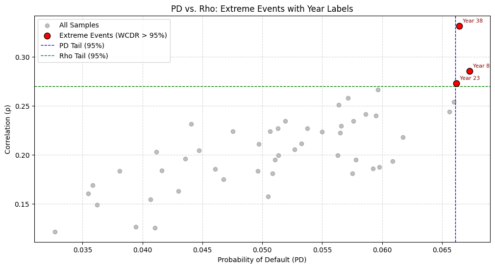

```python
import numpy as np
import scipy.stats as stats
import matplotlib.pyplot as plt

# Generate samples
mean_pd = 0.05
mean_rho = 0.2
cov_matrix = [[0.01**2, 0.0004], [0.0004, 0.05**2]]

np.random.seed(42)
samples = stats.multivariate_normal.rvs(
    mean=[mean_pd, mean_rho],
    cov=cov_matrix,
    size=50
)

samples[:, 0] = np.clip(samples[:, 0], 0.0001, 0.9999)
samples[:, 1] = np.clip(samples[:, 1], 0.0001, 0.9999)


# Compute WCDR and identify extremes
def wcdr(pd, rho):
    numerator = stats.norm.ppf(pd) + np.sqrt(rho) * stats.norm.ppf(0.999)
    denominator = np.sqrt(1 - rho)
    return stats.norm.cdf(numerator / denominator)

wcdr_yearly = [wcdr(pd, rho) for pd, rho in samples]
threshold = np.percentile(wcdr_yearly, 95)
extreme_mask = np.array(wcdr_yearly) > threshold
extreme_years = np.arange(1, 51)[extreme_mask]
extreme_pd = samples[extreme_mask, 0]
extreme_rho = samples[extreme_mask, 1]


# ================================================
# Plot 1: WCDR Time Series with Extreme Events
# ================================================
plt.figure(figsize=(12, 5))
plt.plot(np.arange(1, 51), wcdr_yearly, color='blue', linewidth=1.5, label='WCDR')
plt.scatter(extreme_years, np.array(wcdr_yearly)[extreme_mask],
            color='red', s=50, label='Extreme Events')

# Annotate extreme years
for year in extreme_years:
    plt.annotate(f'Year {year}',
                 (year, wcdr_yearly[year-1]),
                 textcoords="offset points",
                 xytext=(0,10),
                 ha='center')

plt.xlabel('Year')
plt.ylabel('WCDR')
plt.title('WCDR Over 50 Years: Extreme Events Highlighted')
plt.xlabel('Year')
plt.ylabel('WCDR')
plt.title('WCDR Over 50 Years with Extreme Events')
plt.legend()
plt.grid(True, linestyle='--', alpha=0.5)
plt.show()

# ================================================
# Plot 2: 2D PD vs. Rho with Year Labels and Tails
# ================================================
pd_tail = np.percentile(samples[:, 0], 95)
rho_tail = np.percentile(samples[:, 1], 95)

plt.figure(figsize=(12, 6))
plt.scatter(samples[:, 0], samples[:, 1], color='gray', alpha=0.5, label='All Samples')
plt.scatter(extreme_pd, extreme_rho, color='red', s=80, edgecolor='black',
            label='Extreme Events (WCDR > 95%)', zorder=3)

# Annotate extreme years
for pd_val, rho_val, year in zip(extreme_pd, extreme_rho, extreme_years):
    plt.annotate(f'Year {year}', (pd_val, rho_val),
                 textcoords="offset points", xytext=(5,5),
                 ha='left', fontsize=8, color='darkred')

plt.axvline(pd_tail, color='blue', linestyle='--', linewidth=1, label='PD Tail (95%)')
plt.axhline(rho_tail, color='green', linestyle='--', linewidth=1, label='Rho Tail (95%)')
plt.xlabel('Probability of Default (PD)')
plt.ylabel('Correlation (ρ)')
plt.title('PD vs. Rho: Extreme Events with Year Labels')
plt.legend(loc='upper left')
plt.grid(True, linestyle='--', alpha=0.5)
plt.show()
```

## III. Underlying Mechanisms

زمانی که هر دو این پارامترها به طور همزمان افزایش می یابند، اثر تشدیدکننده ای بر ریسک سیستماتیک ایجاد می شود. مکانیزم اصلی این است که در شرایط بحرانی شوک های خارجی (مانند رکود اقتصادی، افت شدید بازارها، یا بحران های سیاسی) باعث افزایش ناگهانی تعداد نکولها می شوند. همزمان این شوک ها سبب افزایش همبستگی بین دارایی ها می گردند؛ زیرا سرمایه گذاران به طور جمعی از بازارهای پرریسک خارج شده و دارایی های مشابه را می فروشند. این همبستگی بالا ریسک سیستماتیک را تقویت می کند؛ زیرا زیان ها دیگر مستقل نیستند و به صورت زنجیره ای گسترش می یابند.

از نظر تاریخی این الگو شبیه به بحران مالی ۲۰۰۸ است. در آن بحران وام های مسکن پرریسک به ابزارهای مالی پیچیده تر تبدیل شدند که همبستگی بالایی با یکدیگر داشتند. هنگامی که قیمت مسکن کاهش یافت نکول‌های گسترده رخ داد و همبستگی بین این ابزارها نیز به طور ناگهانی افزایش یافت . این تعامل باعث تشدید زیان‌ها شد. مدل واسییک این پویایی را با شبیه سازی همزمان PD و ρ نشان می‌دهد، به طوری که در سال‌های بحرانی، WCDR به طور غیرخطی افزایش می‌یابد.

با این حال دو نکته در مدل واسییک در نظر گرفته نشده است. اولاً فرض توزیع نرمال برای PD و ρ ممکن است رفتار واقعی بازار را به درستی منعکس نکند. در واقعیت وقایع فرین بسیار محتمل‌تر از آن چیزی هستند که توزیع نرمال پیشبینی می‌کند. ثانیاً همبستگی در مدل واسسیک ثابت فرض می‌شوذ؛ در حالی که در بحران‌های واقعی همبستگی‌ها می‌توانند به طور پویا تغییر کنند. این تغییرات پویا در مدل در نظر گرفته نشده است.

# P3) Expected shortfall and VaR

داده‌های این سوال از ۵ فروردین ۱۳۹۸ تا ۲۸ اسفند ۱۴۰۳ را به ترتیب صعودی در بر می‌گیرد.

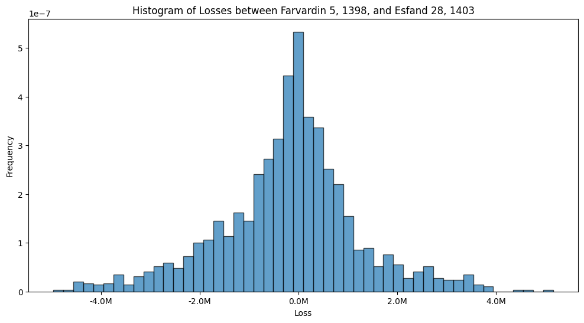

```python
import pandas as pd
import numpy as np
import matplotlib.pyplot as plt

# Load TEDPIX dataset
df = pd.read_csv('TEDPIX.csv')
investment = 100_000_000  # 100 million IRR

# Calculate daily returns and absolute losses
returns = df['Value'].pct_change().dropna()
absolute_losses = (-returns) * investment

# Plot histogram
plt.figure(figsize=(12, 6))
n, bins, patches = plt.hist(absolute_losses,
                           bins=50,
                           density=True,
                           alpha=0.7,
                           edgecolor='k')

plt.title('Histogram of Losses between Farvardin 5, 1398, and Esfand 28, 1403')
plt.xlabel(r'Loss')
plt.ylabel(r'Frequency')

# Format x-axis in millions
plt.gca().xaxis.set_major_formatter(plt.FuncFormatter(lambda x, _: f'{x/1e6:.1f}M'))
plt.show()
```

## I. Historical simulation

```python
import pandas as pd
import numpy as np
import matplotlib.pyplot as plt

confidence_level = 0.99

# Initial investment
investment = 100_000_000  # 100,000,000

# Read data
df = pd.read_csv('TEDPIX.csv')
returns = df['Value'].pct_change().dropna()


# Sort data and calculate risk metrics
sorted_losses = pd.DataFrame({
    'Loss': -returns * investment,
    'Scenario': returns.index + 1
}).sort_values(by='Loss', ascending=False).reset_index(drop=True)

n = len(sorted_losses)
tail_size = int((1 - confidence_level) * n)  # Number of tail observations
tail_data = sorted_losses.iloc[:tail_size]
var = tail_data['Loss'].iloc[-1]
es = tail_data['Loss'].mean()


# Print results
print("\nScenario Number    Loss")
print("-----------------------")

for i in range(tail_size + 2):
    row = sorted_losses.iloc[i]

    # Highlight VAR line
    if i == tail_size - 1:
        print("-"*23)
        print(f"{row['Scenario']:<17g} {row['Loss']:,.0f}    VAR ({confidence_level*100:.1f}%)")
    else:
        print(f"{row['Scenario']:<17g} {row['Loss']:,.0f}")

print("...")
print("...")

# Final results
print("\nFinal Risk Measures:")
print("-------------------")
print(f"VaR ({confidence_level*100:.1f}%): {var:,.0f}")
print(f"ES  ({confidence_level*100:.1f}%): {es:,.0f}")
```

```
Scenario Number    Loss
-----------------------
986               5,153,708
335               4,713,047
188               4,364,857
340               3,764,626
417               3,762,023
985               3,749,907
338               3,732,089
27                3,676,158
334               3,653,470
927               3,618,123
28                3,532,332
280               3,511,782
439               3,506,588
-----------------------
364               3,498,549    VAR (99.0%)
359               3,454,447
906               3,449,190
...
...

Final Risk Measures:
-------------------
VaR (99.0%): 3,498,549
ES  (99.0%): 3,874,090
```

## II. Exponential weighting

برای مشاهده‌ها وزنی پیشنهاد نشده است. با وزن پیشنهادی کتاب $\mathcal{\lambda}=0.9999$ وزن‌ دهی می‌کنم. البته کتاب برای انتخاب $\mathcal{\lambda}$ روش پس آزمایی را برای مقدارهای مختلف پیشنهاد می‌کند. ولی مشاهده من این بود که برای مقدارهای کوچک‌تر مجموع وزن‌ها بسیار کند به حد لازم سطح اطمینان می‌رسد و همچنین VaR با حالت معمولی بسیار متفاوت می‌شود. زیرا مشاهده‌های بزرگ زیادی در زمان‌های قدیمی وجود دارد و وزن آنها بسیار کوچک است. بنابراین به طور شهودی چیزی که مد نظر ما از وزن دهی است بی فایده می‌شود.

```python
import pandas as pd
import numpy as np

# Initialize parameters
investment = 100_000_000
confidence_level = 0.99
lambda_factor = 0.9999

# Load and prepare data
df = pd.read_csv('TEDPIX.csv')
returns = df['Value'].pct_change().dropna()

# Calculate exponential weights
n = len(returns)
weights = np.array([(1 - lambda_factor) * lambda_factor**i for i in range(n)][::-1])
weights /= weights.sum()

# Sort data and calculate risk measures
loss_df = pd.DataFrame({
    'Scenario': returns.index + 1,
    'Loss': -returns.values * investment,
    'Weight': weights
}).sort_values(by='Loss', ascending=False).reset_index(drop=True)

loss_df['Cumulative Weight'] = loss_df['Weight'].cumsum()

var_idx = np.argmax(loss_df['Cumulative Weight'] >= (1 - confidence_level))
var = loss_df.loc[var_idx, 'Loss']
es = np.average(loss_df.loc[:var_idx, 'Loss'], weights=loss_df.loc[:var_idx, 'Weight'])

# Print results
print("\nScenario   Loss (%)   Weight        Cumulative Weight")
print("-----------------------------------------------------")

for i in range(var_idx + 2):
    row = loss_df.iloc[i]
    scenario = row['Scenario']
    loss_pct = row['Loss']
    weight = row['Weight']
    cum_weight = row['Cumulative Weight']

    # Print VaR separator
    if i == var_idx:
        print("-----------------------------------------------------")
        print(f"{scenario:<10g} {loss_pct:,.0f}     {weight:.4f}       {cum_weight:.4f}    VAR ({confidence_level*100}%)")
    else:
        print(f"{scenario:<10g} {loss_pct:,.0f}     {weight:.4f}       {cum_weight:.4f}")

print("...")
print("...")

# Print final metrics
print("\nRisk Measures:")
print("-------------")
print(f"VaR ({confidence_level*100}%): {var:,.0f}")
print(f"ES  ({confidence_level*100}%): {es:,.0f}")
```

```
Scenario   Loss (%)   Weight        Cumulative Weight
-----------------------------------------------------
986        5,153,708     0.0007       0.0007
335        4,713,047     0.0007       0.0014
188        4,364,857     0.0007       0.0020
340        3,764,626     0.0007       0.0027
417        3,762,023     0.0007       0.0034
985        3,749,907     0.0007       0.0041
338        3,732,089     0.0007       0.0048
27         3,676,158     0.0006       0.0054
334        3,653,470     0.0007       0.0061
927        3,618,123     0.0007       0.0068
28         3,532,332     0.0006       0.0074
280        3,511,782     0.0007       0.0081
439        3,506,588     0.0007       0.0088
364        3,498,549     0.0007       0.0095
-----------------------------------------------------
359        3,454,447     0.0007       0.0101    VAR (99.0%)
906        3,449,190     0.0007       0.0108
...
...

Risk Measures:
-------------
VaR (99.0%): 3,454,447
ES  (99.0%): 3,850,754
```

## III. Volatility-scaling

برای تخمین واریانس با مدل GARCH از کتابخانه `arch` استفاده کردم. با فرستادن `backcast=returns.var()` به تابع برازش مدل واریانس ابتدایی را برابر با واریانس نمونه قرار می‌دهم.

خواسته سوال در مورد برازش مدل‌ EWMA را متوجه نشدم چون جایی از آن استفاده نمی‌شود.

```python
import pandas as pd
!pip install arch -q
from arch import arch_model

data = pd.read_csv('TEDPIX.csv')
returns = data['Value'].pct_change().dropna()

# Fit GARCH(1,1) with sample variance initialization
model = arch_model(returns, mean='Constant', vol='GARCH', p=1, q=1, rescale=False)
results = model.fit(backcast=returns.var(), update_freq=0, disp='off')

print(results.summary())

# Get volatilities
historical_vol = results.conditional_volatility
current_vol = np.sqrt(results.forecast(horizon=1).variance.iloc[-1, 0])

# Scale returns, sort data and calculate risk metrics
scaled_returns = returns * (current_vol / historical_vol)

sorted_losses = pd.DataFrame({
    'Loss': -scaled_returns * investment,
    'Scenario': returns.index + 1
}).sort_values(by='Loss', ascending=False).reset_index(drop=True)

n = len(sorted_losses)
tail_size = int((1 - confidence_level) * n)  # Number of tail observations
tail_data = sorted_losses.iloc[:tail_size]
var = tail_data['Loss'].iloc[-1]
es = tail_data['Loss'].mean()


# Print results
print("\nScenario Number    Loss")
print("-----------------------")

for i in range(tail_size + 2):
    row = sorted_losses.iloc[i]

    # Highlight VAR line
    if i == tail_size - 1:
        print("-"*23)
        print(f"{row['Scenario']:<17g} {row['Loss']:,.0f}    VAR ({confidence_level*100:.1f}%)")
    else:
        print(f"{row['Scenario']:<17g} {row['Loss']:,.0f}")

print("...")
print("...")

# Final results
print("\nFinal Risk Measures:")
print("-------------------")
print(f"VaR ({confidence_level*100:.1f}%): {var:,.0f}")
print(f"ES  ({confidence_level*100:.1f}%): {es:,.0f}")
```

```
                     Constant Mean - GARCH Model Results
==============================================================================
Dep. Variable:                  Value   R-squared:                       0.000
Mean Model:             Constant Mean   Adj. R-squared:                  0.000
Vol Model:                      GARCH   Log-Likelihood:                4246.63
Distribution:                  Normal   AIC:                          -8485.26
Method:            Maximum Likelihood   BIC:                          -8464.18
                                        No. Observations:                 1437
Date:                Thu, May 15 2025   Df Residuals:                     1436
Time:                        20:02:08   Df Model:                            1
                                 Mean Model
============================================================================
                 coef    std err          t      P>|t|      95.0% Conf. Int.
----------------------------------------------------------------------------
mu         8.8822e-04  3.332e-06    266.573      0.000 [8.817e-04,8.947e-04]
                              Volatility Model
============================================================================
                 coef    std err          t      P>|t|      95.0% Conf. Int.
----------------------------------------------------------------------------
omega      3.9762e-06  3.144e-12  1.265e+06      0.000 [3.976e-06,3.976e-06]
alpha[1]       0.1000  2.457e-02      4.070  4.708e-05   [5.184e-02,  0.148]
beta[1]        0.8800  2.216e-02     39.704      0.000     [  0.837,  0.923]
============================================================================

Covariance estimator: robust

Scenario Number    Loss
-----------------------
188               4,347,326
1087              3,443,462
74                3,301,161
1101              3,288,783
986               3,218,751
1237              3,208,707
1212              3,057,217
927               3,033,913
985               3,018,297
582               3,009,902
27                2,919,472
417               2,859,589
1030              2,824,537
-----------------------
1006              2,814,276    VAR (99.0%)
840               2,735,136
1282              2,725,054
...
...

Final Risk Measures:
-------------------
VaR (99.0%): 2,814,276
ES  (99.0%): 3,167,528
```

### 😩

تلاش کردم یک مدل GARCH با کمک هوش مصنوعی بنویسم؛ ولی ظاهرا بهینه‌سازی خوب کار نمی‌کند و پارامترها به روشنی غلط است. به همین خاطر از مدل‌های از پیش ساخته استفاده کردم.

```python
import numpy as np
from scipy.optimize import minimize

class GARCH11:
    def __init__(self):
        self.params = None  # [omega, alpha, beta]
        self.data = None
        self.sigma2 = None  # Estimated variances

    def fit(self, data):
        self.data = data
        n = len(data)

        # Initial parameter guess [omega, alpha, beta]
        initial_params = np.array([np.var(data) * 0.1, 0.1, 0.8])

        # Bounds: omega > 0, alpha >= 0, beta >= 0
        bounds = [(1e-6, None), (0, None), (0, None)]

        # Optimize parameters
        result = minimize(
            self._negative_log_likelihood,
            initial_params,
            args=(data,),
            bounds=bounds,
            method='L-BFGS-B'
        )

        if result.success:
            self.params = result.x
            self.sigma2 = self._compute_sigma2(data, self.params)
        else:
            raise RuntimeError("Optimization failed: " + result.message)

    def _negative_log_likelihood(self, params, data):
        omega, alpha, beta = params
        n = len(data)
        sigma2 = np.zeros(n)
        sigma2[0] = np.var(data)  # Initialize with unconditional variance

        for t in range(1, n):
            sigma2[t] = omega + alpha * data[t-1]**2 + beta * sigma2[t-1]

        if np.any(sigma2 <= 0):
            return np.inf  # Invalid variance

        # Log-likelihood (assuming normal distribution)
        log_likelihood = -np.sum(np.log(sigma2) + (data**2) / sigma2)
        return -log_likelihood  # Return negative for minimization

    def _compute_sigma2(self, data, params):
        # Recompute variances with optimized parameters
        omega, alpha, beta = params
        n = len(data)
        sigma2 = np.zeros(n)
        sigma2[0] = np.var(data)

        for t in range(1, n):
            sigma2[t] = omega + alpha * data[t-1]**2 + beta * sigma2[t-1]

        return sigma2

    def forecast(self, horizon=1):
        if self.params is None:
            raise RuntimeError("Model not fitted. Call fit() first.")

        omega, alpha, beta = self.params
        last_residual2 = self.data.iloc[-1]**2  # Last squared residual
        last_variance = self.sigma2[-1]     # Last estimated variance
        forecasts = []

        for _ in range(horizon):
            next_var = omega + alpha * last_residual2 + beta * last_variance
            forecasts.append(next_var)
            last_residual2 = next_var  # Assume residual = 0 for future steps
            last_variance = next_var

        return forecasts



# Load and prepare data
data = pd.read_csv('TEDPIX.csv')
returns = data['Value'].pct_change().dropna().reset_index(drop=True)

model = GARCH11()
model.fit(returns)


print("Fitted parameters:", model.params)
```

```
Fitted parameters: [7.33871066e-06 1.69872284e-01 7.99678653e-01]
```

## IV. Extreme value theory

برای این بخش باید بر دم توزیع ضررها یک توزیع پارتو تعمیم یافته برازش کنم. این کار را با استفاده از آبجکت `genpareto` در `sipy.stats` انجام دادم.

```python
import pandas as pd
import numpy as np
from scipy.stats import genpareto

# Initialize parameters
investment = 100_000_000
evt_confidence = 0.99

# Load and prepare data
df = pd.read_csv('TEDPIX.csv')
returns = df['Value'].pct_change().dropna()

# Calculate threshold (u) at 95th percentile
losses = (-returns).values
u = np.percentile(losses, 95)
excesses = losses[losses > u] - u

# Fit generalized Pareto distribution
params = genpareto.fit(excesses, floc=0)
xi, _, beta = params

# Calculate risk emasures
n_total = len(losses)
n_excess = len(excesses)

var_evt = u + (beta/xi) * (((n_total/n_excess)*(1 - evt_confidence))**(-xi) - 1)

es_evt = (var_evt + beta - xi*u)/(1 - xi)

# 4. Print results
print("\nEVT Risk Metrics")
print("="*40)
print(f"Threshold (u) at 95th percentile: {u*investment:,.0f}")
print(f"GPD Parameters: ξ={xi:.4f}, β={beta*100:.2f}%")
print(f"Number of Excesses: {n_excess}")
print("-"*40)

# Print final metrics
print("\nFinal EVT Results:")
print("-"*40)
print(f"EVT VaR ({evt_confidence*100}%): {var_evt*investment:,.0f}")
print(f"EVT ES  ({evt_confidence*100}%): {es_evt*investment:,.0f}")
```

```
EVT Risk Metrics
========================================
Threshold (u) at 95th percentile: 2,266,780
GPD Parameters: ξ=-0.2365, β=0.90%
Number of Excesses: 72
----------------------------------------

Final EVT Results:
----------------------------------------
EVT VaR (99.0%): 3,476,804
EVT ES  (99.0%): 3,975,659
```

## V. Analyze and interpret

در مورد روش وزن دهی نمایی نمی‌توان اظهار نظری کرد؛ زیرا مقدار پارامتر بسیار تعیین کننده است و این مقدار باید با پس آزمایی انتخاب شود. پس بدون پس آزمایی نمی‌توانم نتیجه آن را ارزیابی کنم.

در مورد نتیجه نظریه فرین هم که با شبیه سازی تاریخی معمولی نزدیکی زیادی دارد فقط این نکته وجود دارد که سطح اطمینان خواسته شده نیاز به استفاده از این نظریه ندارد

## VI. Back-Test

برای پس آزمایی از VaR نظریه فرین استفاده کردم. آزمون کوپیک با نوشتن رابطه راست‌نمایی و سپس محاسبه p-value با استفاده از توزیع $\mathcal{\chi}^2$ انجام می‌شود. آزمون کریستوفرسن هم برای بانچینگ مطابق ساز و کار کتاب انجام می‌شود. به ازای این VaR آزمون کوپپیک پذیرفته می‌شود؛ ولی آزمون کریستوفرسن رد می‌شود. این موضوع را می‌توان در نمودار هم مشاهده کرد: استثناها در دو ناحیه فشرده شده‌ اند.

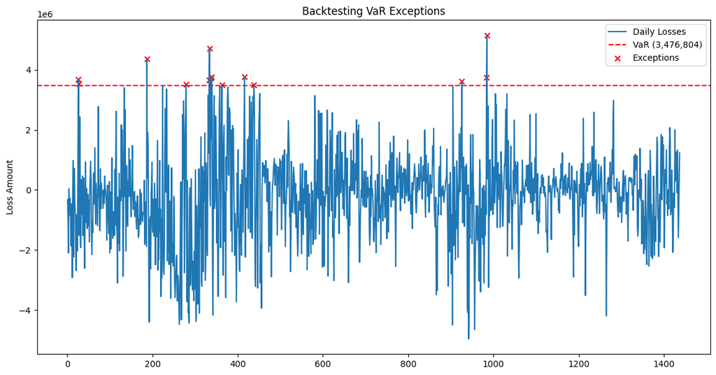

```
Backtesting Results
========================================
Total Observations: 1438
VaR Level: 99.0%
User-defined VaR: 3,476,804
Number of Exceptions: 14
Expected Exceptions: 14.4
Exception Rate: 0.97%

Kupiec Test:
Likelihood Ratio: 0.01
P-value: 0.9194
Reject Model: No

Christoffersen:
Likelihood Ratio: 14.10
P-value: 0.0002
Reject Model: Yes
```

```python
import pandas as pd
import numpy as np
import matplotlib.pyplot as plt
from scipy.stats import chi2

# Initialize parameters
investment = 100_000_000
var_level = 0.99          # VaR confidence level
significance = 0.05        # Significance level
determined_var = 3_476_804    # EVT VaR


# Load and prepare data
df = pd.read_csv('TEDPIX.csv')
returns = df['Value'].pct_change().dropna()
df['Loss'] = -returns * investment

# Plot of returns and exceptions
plt.figure(figsize=(14, 7))
plt.plot(df.index, df['Loss'], label='Daily Losses')
plt.axhline(y=determined_var, color='r', linestyle='--', label=f'VaR ({determined_var:,.0f})')
plt.scatter(df[df['Loss'] > determined_var].index,
            df[df['Loss'] > determined_var]['Loss'],
            color='red', marker='x', label='Exceptions')
plt.title('Backtesting VaR Exceptions')
plt.ylabel('Loss Amount')
plt.legend()
plt.show()

# Test statistics
n = len(df)
exceptions = df['Loss'] > determined_var
x = exceptions.sum()
p = 1 - var_level

# Kupiec two-tailed test-------------------------------------------------------
def kupiec_test(x, n, p):
    likelihood_ratio = -2 * (np.log((p**x) * ((1 - p)**(n - x))) -
                            np.log(((x/n)**x) * ((1 - x/n)**(n - x))))
    p_value = 1 - chi2.cdf(likelihood_ratio, df=1)
    return likelihood_ratio, p_value

lr_kupiec, p_kupiec = kupiec_test(x, n, p)

# Christoffersen's test for bunching-------------------------------------------
def christoffersen_test(exceptions, alpha=0.05):
    T = exceptions.astype(int)
    transitions = pd.DataFrame({
        't0': T[:-1].values,
        't1': T[1:].values
    })

    n00 = ((transitions['t0'] == 0) & (transitions['t1'] == 0)).sum()
    n01 = ((transitions['t0'] == 0) & (transitions['t1'] == 1)).sum()
    n10 = ((transitions['t0'] == 1) & (transitions['t1'] == 0)).sum()
    n11 = ((transitions['t0'] == 1) & (transitions['t1'] == 1)).sum()

    pi0 = n01 / (n00 + n01) if (n00 + n01) > 0 else 0
    pi1 = n11 / (n10 + n11) if (n10 + n11) > 0 else 0
    pi = (n01 + n11) / (n00 + n01 + n10 + n11)

    if pi0 + pi1 == 0:
        return 0, 1.0
    LR_ind = -2 * ((n00 + n10) * np.log(1 - pi) + (n01 + n11) * np.log(pi) -
             (n00 * np.log(1 - pi0) + n01 * np.log(pi0) +
             n10 * np.log(1 - pi1) + n11 * np.log(pi1)))

    p_value = 1 - chi2.cdf(LR_ind, df=1)
    return LR_ind, p_value

lr_christ, p_christ = christoffersen_test(exceptions)

# Print results
print("\nBacktesting Results")
print("="*40)
print(f"Total Observations: {n}")
print(f"VaR Level: {var_level*100}%")
print(f"User-defined VaR: {determined_var:,.0f}")
print(f"Number of Exceptions: {x}")
print(f"Expected Exceptions: {n*p:.1f}")
print(f"Exception Rate: {x/n:.2%}")

print("\nKupiec Test:")
print(f"Likelihood Ratio: {lr_kupiec:.2f}")
print(f"P-value: {p_kupiec:.4f}")
print(f"Reject Model: {'Yes' if p_kupiec < significance else 'No'}")

print("\nChristoffersen:")
print(f"Likelihood Ratio: {lr_christ:.2f}")
print(f"P-value: {p_christ:.4f}")
print(f"Reject Model: {'Yes' if p_christ < significance else 'No'}")
```

```python
import pandas as pd
import numpy as np
import matplotlib.pyplot as plt
from scipy.stats import chi2

# Configuration
INVESTMENT = 100_000_000  # 100 million currency units
CONFIDENCE_LEVEL = 0.95
SIGNIFICANCE_LEVEL = 0.05
USER_VAR = 4_500_000  # Set your VaR threshold here (in absolute terms)

# Load and prepare data
def load_data():
    df = pd.read_csv('TEDPIX.csv', parse_dates=['dateissue'])
    df['returns'] = df['value'].pct_change().dropna()
    df['absolute_loss'] = (-df['returns']) * INVESTMENT
    return df

# Backtesting visualizations
def plot_backtest_results(losses, var_threshold):
    plt.figure(figsize=(12, 6))
    plt.plot(losses.index, losses, label='Daily Losses')
    plt.axhline(var_threshold, color='r', linestyle='--', label=f'VaR ({var_threshold/1e6:.1f}M)')

    # Highlight exceptions
    exceptions = losses[losses > var_threshold]
    plt.scatter(exceptions.index, exceptions, color='red', label='Exceptions')

    plt.title('VaR Backtesting Results')
    plt.ylabel('Loss Amount')
    plt.legend()
    plt.grid(True)
    plt.show()

# Statistical tests
def kupiec_test(n_obs, n_exc, var_level):
    p = 1 - var_level
    likelihood_ratio = 2 * (np.log((n_exc/n_obs)**n_exc * (1 - n_exc/n_obs)**(n_obs - n_exc)
                          - np.log(p**n_exc * (1 - p)**(n_obs - n_exc)))
    p_value = 1 - chi2.cdf(likelihood_ratio, df=1)
    return likelihood_ratio, p_value

def christoffersen_test(exceptions):
    transitions = np.zeros((2, 2))

    for t in range(1, len(exceptions)):
        prev = int(exceptions[t-1])
        curr = int(exceptions[t])
        transitions[prev, curr] += 1

    n0 = transitions[0].sum()
    n1 = transitions[1].sum()

    p01 = transitions[0, 1]/n0 if n0 > 0 else 0
    p11 = transitions[1, 1]/n1 if n1 > 0 else 0
    p_total = exceptions.mean()

    ll_unrestricted = transitions[0, 1]*np.log(p01) + transitions[0, 0]*np.log(1-p01)
    ll_unrestricted += transitions[1, 1]*np.log(p11) + transitions[1, 0]*np.log(1-p11)

    ll_restricted = exceptions.sum()*np.log(p_total)
    ll_restricted += (len(exceptions) - exceptions.sum())*np.log(1 - p_total)

    lr = -2 * (ll_restricted - ll_unrestricted)
    p_value = 1 - chi2.cdf(lr, df=1)
    return lr, p_value

# Main analysis
if __name__ == "__main__":
    # Load and process data
    data = load_data()

    # Backtesting visualization
    plot_backtest_results(data['absolute_loss'], USER_VAR)

    # Calculate exceptions
    exceptions = data['absolute_loss'] > USER_VAR
    n_observations = len(data)
    n_exceptions = exceptions.sum()

    # Run statistical tests
    lr_kupiec, p_kupiec = kupiec_test(n_observations, n_exceptions, CONFIDENCE_LEVEL)
    lr_christ, p_christ = christoffersen_test(exceptions)

    # Print results
    print(f"Backtesting Results for VaR {USER_VAR/1e6:.1f}M")
    print("="*40)
    print(f"Observation period: {data['dateissue'].min().date()} to {data['dateissue'].max().date()}")
    print(f"Total observations: {n_observations}")
    print(f"Expected exceptions: {(1 - CONFIDENCE_LEVEL) * n_observations:.1f}")
    print(f"Actual exceptions: {n_exceptions}")
    print("\nKupiec Test (Unconditional Coverage):")
    print(f"LR Statistic: {lr_kupiec:.4f}, p-value: {p_kupiec:.4f}")
    print(f"Conclusion: {'Valid' if p_kupiec > SIGNIFICANCE_LEVEL else 'Invalid'} model")
    print("\nChristoffersen Test (Independence):")
    print(f"LR Statistic: {lr_christ:.4f}, p-value: {p_christ:.4f}")
    print(f"Conclusion: {'No clustering' if p_christ > SIGNIFICANCE_LEVEL else 'Clustering detected'}")

    # Final validation
    validation = (p_kupiec > SIGNIFICANCE_LEVEL) and (p_christ > SIGNIFICANCE_LEVEL)
    print("\nOverall Model Validation:", "PASS" if validation else "FAIL")
```

[output not shown]

# P4) Your Portfolio!

برای این سوال چهار نماد خودرو، وبصادر، فملی، و طلا را در نظر گرفتم. قیمت‌ها برای بیش از ۵۰۰ روز گذشته است.

## I. Compute Correlation Matrix

برای محاسبه کوواریانس روش خاصی پیشنهاد نشده است. از روش وزن‌دهی برابر استفاده می‌کنم.

```python
import pandas as pd

# Read data from CSV
df = pd.read_csv('4assets.csv', parse_dates=['date'], index_col='date')

# Calculate daily returns
returns = df.pct_change().dropna()

# Compute correlation matrix
correlation_matrix = returns.corr()

print("Correlation Matrix:\n")
print(correlation_matrix)
```

```
Correlation Matrix:

                iran_khodro  s_inc_ind  saderat_bank  lotus_gold_etf
iran_khodro        1.000000   0.020627     -0.000036        0.041918
s_inc_ind          0.020627   1.000000      0.016261        0.003911
saderat_bank      -0.000036   0.016261      1.000000       -0.006955
lotus_gold_etf     0.041918   0.003911     -0.006955        1.000000
```

## II. Minimum Variance Portfolio Optimization

برای این قسمت مسأله زیر باید حل شود

\begin{aligned} & \underset{\mathbf{w}}{\text{minimize}} & & \sigma_p^2 = \mathbf{w}^T \Sigma \mathbf{w} \\ & \text{s.t} & & \sum_{i=1}^n w_i = 1 \quad \text{(sum of weights)} \\ & & & 0 \leq w_i \leq 1 \quad \forall i \quad \text{(No short-selling)} \end{aligned}

تبدیل کوواریانس به سالانه برای یکسان‌سازی معیارهای ریسک با استاندارد صنعتی انجام شده و در صورت نیاز می‌توان آن را حذف کرد.

تابع هدف به صورت واریانس سبد (ضرب ماتریسی وزن‌ها در ماتریس کوواریانس) تعریف می‌شود، محدودیت اصلی برابر بودن مجموع وزن‌ها با ۱ (تخصیص کامل سرمایه) و بازه مجاز وزن‌ها بین ۰ تا ۱ (ممنوعیت فروش استقراضی) تنظیم می‌گردد و بهینه‌سازی با الگوریتم SLSQP انجام می‌شود که توانایی حل مسائل غیرخطی با محدودیت‌های ترکیبی را دارد

```python
import pandas as pd
import numpy as np
from scipy.optimize import minimize

# Read data from CSV
df = pd.read_csv('4assets.csv', parse_dates=['date'], index_col='date')

# Calculate daily returns
returns = df.pct_change().dropna()

# Annualized covariance matrix (assuming daily data)
cov_matrix = returns.cov() * 252

# Objective function: Portfolio variance
def portfolio_variance(weights, cov_matrix):
    return weights.T @ cov_matrix @ weights

# Constraints and bounds
n_assets = len(df.columns)  # Number of assets
constraints = ({'type': 'eq', 'fun': lambda x: np.sum(x) - 1})  # Sum of weights
bounds = tuple((0, 1) for _ in range(n_assets))  # No short-selling
init_guess = [1/n_assets] * n_assets  # Equal weights

# Optimization
result = minimize(
    portfolio_variance,
    init_guess,
    args=(cov_matrix,),
    method='SLSQP',
    bounds=bounds,
    constraints=constraints
)

optimal_weights = result.x
print("Optimal Weights:")
for asset, weight in zip(df.columns, optimal_weights):
    print(f"{asset}: {weight:.4f}")

print("\nPortfolio Variance:", result.fun)
```

```
Optimal Weights:
iran_khodro: 0.0033
s_inc_ind: 0.3180
saderat_bank: 0.0262
lotus_gold_etf: 0.6525

Portfolio Variance: 0.08849009186767423
```

## III. Calculate 99% VaR and ES

سنجه‌های خواسته شده با استفاده از توزیع‌های ضرر و به صورت صدک ۹۹ ام و میانگین دم بزرگتر از این صدک آن گزارش می‌شود.

وزن‌های بخش قبل مجدداً با کدی مختصرتر محاسبه شده اند تا بخش‌ها مستقل باشند.

```python
import pandas as pd
import numpy as np
from scipy.optimize import minimize

# Load data
data = pd.read_csv('4assets.csv', parse_dates=['date'], index_col='date')

# Calculate returns
returns = data.pct_change().dropna()

# Redo Part II to find minimum variance portfolio
cov_matrix = returns.cov() * 252
n_assets = len(data.columns)
result = minimize(lambda w: w @ cov_matrix @ w,
                  x0=[1/n_assets]*n_assets,
                  method='SLSQP',
                  bounds=[(0,1)]*n_assets,
                  constraints={'type': 'eq', 'fun': lambda w: np.sum(w)-1})
optimal_weights = result.x

# Part III: Calculate VaR and ES
portfolio_value = 100_000_000
portfolio_loss = -returns @ optimal_weights * portfolio_value
var_99 = np.percentile(portfolio_loss, 99)
es_99 = portfolio_loss[portfolio_loss >= np.percentile(portfolio_loss, 99)].mean()

print(f"99% VaR: {var_99:,.0f} IRR")
print(f"99% ES: {es_99:,.0f} IRR")
```

```
99% VaR: 4,874,525 IRR
99% ES: 6,206,267 IRR
```

## IV. Marginal VaR, Incremental VaR, and Component VaR

VaR حاشیه‌ای را با تغییر وزن دارایی پرریسک به اندازه ٪۰.۰۱ محاسبه کردم. VaR افزایشی هم با مقایسه VaR بعد از حذف دارایی انجام می‌شود. سبد جدید با دارایی‌های باقی مانده باید دوباره بهینه سازی شود.

```python
import pandas as pd
import numpy as np
from scipy.optimize import minimize

# Load data and calculate returns
data = pd.read_csv('4assets.csv', parse_dates=['date'], index_col='date')
returns = data.pct_change().dropna()
portfolio_value = 100_000_000  # 100 million IRR

# Get original optimal weights with all assets
cov_matrix = returns.cov().values * 252
n_assets = len(data.columns)
result = minimize(lambda w: w @ cov_matrix @ w,
                  x0=[1/n_assets]*n_assets,
                  method='SLSQP',
                  bounds=[(0,1)]*n_assets,
                  constraints={'type': 'eq', 'fun': lambda w: np.sum(w)-1})
original_weights = result.x

# Compute original VaR (Historical Simulation)
portfolio_returns = returns @ original_weights
original_var = -np.percentile(portfolio_returns, 1) * portfolio_value

# Identify most risky asset
risky_asset_idx = np.argmax(np.diag(cov_matrix))
risky_asset_name = data.columns[risky_asset_idx]


# Marginal VaR----------------------------------------------------------------
delta = 1e-4  # 0.01%

new_weights =  original_weights.copy()
new_weights[risky_asset_idx] += delta
delta_loss = -returns @ new_weights * portfolio_value
delta_var = np.percentile(delta_loss, 99)
marginal_var = (delta_var - original_var) / delta
#------------------------------------------------------------------------------

# Incremental VaR--------------------------------------------------------------
# Optimize reduced portfolio
reduced_returns = returns.drop(columns=[risky_asset_name])
reduced_cov = reduced_returns.cov().values * 252
n_reduced = len(reduced_returns.columns)

result_reduced = minimize(lambda w: w @ reduced_cov @ w,
                          x0=[1/n_reduced]*n_reduced,
                          method='SLSQP',
                          bounds=[(0,1)]*n_reduced,
                          constraints={'type': 'eq', 'fun': lambda w: np.sum(w)-1})
reduced_weights = result_reduced.x

# VaR without risky asset
reduced_portfolio_returns = reduced_returns @ reduced_weights
reduced_var = -np.percentile(reduced_portfolio_returns, 1) * portfolio_value

incremental_var = original_var - reduced_var
#------------------------------------------------------------------------------

# Component VaR----------------------------------------------------------------
component_var = original_weights[risky_asset_idx] * marginal_var
#------------------------------------------------------------------------------

print(f"Most Risky Asset: {risky_asset_name}")
print(f"Marginal VaR: {marginal_var:,.0f} IRR/%")
print(f"Incremental VaR: {incremental_var:,.0f} IRR")
print(f"Component VaR: {component_var:,.0f} IRR")
```

```
Most Risky Asset: iran_khodro
Marginal VaR: 1,808,760 IRR/%
Incremental VaR: -10,315 IRR
Component VaR: 5,957 IRR
```

## V. Euler’s Theorem

مشابه بخش قبل VaR های حاشیه‌ای را برای هر دارایی محاسبه می‌کنم و سپس به VaR مؤلفه‌ای می‌رسم. با جمع آنها و مقایسه با VaR سبد اصلی و مشاهده تفاضل تئوری اویلر را آزمون می‌کنم. برای مقدار دلتای کوچک این تفاضل بسیار ناچیز است. بنابراین نظریه درست آزمون می‌شود.

```python
import pandas as pd
import numpy as np
from scipy.optimize import minimize

# Load data and calculate returns
data = pd.read_csv('4assets.csv', parse_dates=['date'], index_col='date')
returns = data.pct_change().dropna()
portfolio_value = 100_000_000  # 100 million IRR

# Get optimized weights
cov_matrix = returns.cov().values * 252  # Annualized covariance matrix
n_assets = len(data.columns)
result = minimize(lambda w: w @ cov_matrix @ w,
                  x0=[1/n_assets]*n_assets,
                  method='SLSQP',
                  bounds=[(0,1)]*n_assets,
                  constraints={'type': 'eq', 'fun': lambda w: np.sum(w)-1})
optimal_weights = result.x

# Euler’s Theorem Validation (Numerical)

# 1. Compute Original VaR (Historical Simulation)
portfolio_returns = returns @ optimal_weights
original_var = -np.percentile(portfolio_returns, 1) * portfolio_value

# 2. Calculate Component VaR
delta = 1e-4  # 0.01% perturbation (1 basis point)
component_vars = []

for asset_idx in range(n_assets):
    delta_weights =  original_weights.copy()
    delta_weights[asset_idx] += delta
    delta_loss = -returns @ delta_weights * portfolio_value
    delta_var = np.percentile(delta_loss, 99)
    marginal_var = (delta_var - original_var) / delta
    component_var = optimal_weights[asset_idx] * marginal_var
    component_vars.append(component_var)

# 3. Sum Component VaRs and compare with Portfolio VaR
total_component_var = np.sum(component_vars)
discrepancy = original_var - total_component_var

# Results
print(f"Original Portfolio VaR: {original_var:,.0f} IRR")
print(f"Sum of Component VaRs: {total_component_var:,.0f} IRR")
print(f"Discrepancy: {discrepancy:,.0f} IRR")
```

```
Original Portfolio VaR: 4,874,525 IRR
Sum of Component VaRs: 4,874,525 IRR
Discrepancy: 0 IRR
```

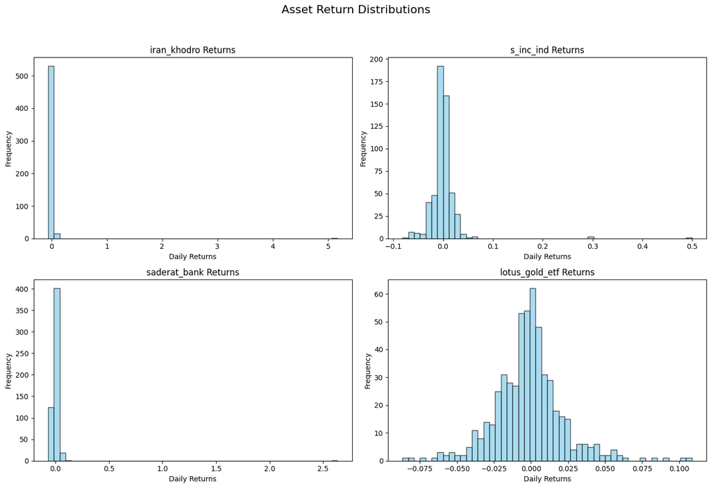

```python
import pandas as pd
import matplotlib.pyplot as plt

# Load data
data = pd.read_csv('4assets.csv', parse_dates=['date'], index_col='date')

# Calculate daily returns
returns = data.pct_change().dropna()

# Create figure with subplots
fig, axes = plt.subplots(nrows=2, ncols=2, figsize=(14, 10))
fig.suptitle('Asset Return Distributions', fontsize=16)

# Flatten axes array for easy iteration
axes = axes.flatten()

# Plot histograms for each asset
for idx, asset in enumerate(returns.columns):
    ax = axes[idx]
    ax.hist(returns[asset], bins=50, color='skyblue', edgecolor='black', alpha=0.7)

    # Add labels and formatting
    ax.set_title(f'{asset} Returns')
    ax.set_xlabel('Daily Returns')
    ax.set_ylabel('Frequency')

plt.tight_layout(rect=[0, 0.03, 1, 0.95])  # Adjust layout
plt.show()
```